# Final Project - Practical Machine Learning

Pushkar Sinngh Bhauryal

December 14, 2015

### Introduction

For this project, we are given data from accelerometers on the belt, forearm, arm, and dumbell of 6 research study participants. Our training data consists of accelerometer data and a label identifying the quality of the activity the participant was doing. Our testing data consists of accelerometer data without the identifying label. Our goal is to predict the labels for the test set observations.

Below is the code I used when creating the model, estimating the out-of-sample error, and making predictions. I also include a description of each step of the process.

### Data

The training data for this project are available here: https://d396qusza40orc.cloudfront.net/predmachlearn/pml-training.csv)

The test data are available here: https://d396qusza40orc.cloudfront.net/predmachlearn/pml-testing.csv

The data for this project come from this source: http://groupware.les.inf.puc-rio.br/har.

#### Requered Library

```r
library(caret)
library(rpart)
```

```r
library(rpart.plot)
library(RColorBrewer)
library(rattle)
library(randomForest)
library(knitr)
library(corrplot)
```

#### Getting and loading the data

```r
ptrain <- read.csv("pml-training.csv")
ptest <- read.csv("pml-testing.csv")
```

Because I want to be able to estimate the out-of-sample error, I randomly split the full training data (ptrain) into a smaller training set (ptrain1) and a validation set (ptrain2):

```r
partition <- createDataPartition(y=ptrain$classe, p=0.7, list=F)
ptrain1 <- ptrain[partition, ]
ptrain2 <- ptrain[-partition, ]
```

Now I’m removing those variable with have maximum valuses as NA, Variance Near by zero and those variable wich do nat have a significance on pridiction.

```r
# Near zero variance

nzv<- nearZeroVar(ptrain1)

ptrain1<- ptrain1[,-nzv]
ptrain2<- ptrain2[,-nzv]

# Mostly NA

mostlyNa<- sapply(ptrain1,function(x) mean(is.na(x)))> 0.95
ptrain1<- ptrain1[,mostlyNa==F]
ptrain2<- ptrain2[,mostlyNa==F]

#non singificance for prediction (X, user_name, raw_timestamp_part_1, raw_timestamp_part_2, cvtd_timestamp), which happen to be the first five variables
ptrain1<- ptrain1[,-(1:5)]
ptrain2<- ptrain2[,-(1:5)]
```

### EVALUATION

#### Classification Tree

```r
modFit <- train(classe ~ ., data = ptrain1, method="rpart")
print(modFit, digits=3)
```

```
## CART
##
## 13737 samples
##    53 predictor
##     5 classes: 'A', 'B', 'C', 'D', 'E'
##
## No pre-processing
## Resampling: Bootstrapped (25 reps)
## Summary of sample sizes: 13737, 13737, 13737, 13737, 13737, 13737, ...
## Resampling results across tuning parameters:
##
##   cp      Accuracy  Kappa   Accuracy SD  Kappa SD
##   0.0391  0.525     0.3839  0.0325       0.0495
##   0.0612  0.407     0.1951  0.0621       0.1031
##   0.1168  0.315     0.0494  0.0422       0.0618
##
## Accuracy was used to select the optimal model using  the largest value.
## The final value used for the model was cp = 0.0391.
```

```r
print(modFit$finalModel, digits=3)
```

```
## n= 13737
##
## node), split, n, loss, yval, (yprob)
##       * denotes terminal node
##
##  1) root 13737 9830 A (0.28 0.19 0.17 0.16 0.18)
##    2) roll_belt< 130 12497 8640 A (0.31 0.21 0.19 0.18 0.11)
##      4) pitch_forearm< -33.2 1138   11 A (0.99 0.0097 0 0 0) *
##      5) pitch_forearm>=-33.2 11359 8630 A (0.24 0.23 0.21 0.2 0.12)
##       10) magnet_dumbbell_y< 440 9596 6920 A (0.28 0.18 0.24 0.19 0.1)
##         20) roll_forearm< 122 5926 3520 A (0.41 0.18 0.19 0.17 0.058) *
##         21) roll_forearm>=122 3670 2440 C (0.075 0.18 0.33 0.23 0.18) *
##       11) magnet_dumbbell_y>=440 1763  852 B (0.032 0.52 0.041 0.22 0.19) *
##    3) roll_belt>=130 1240   46 E (0.037 0 0 0 0.96) *
```

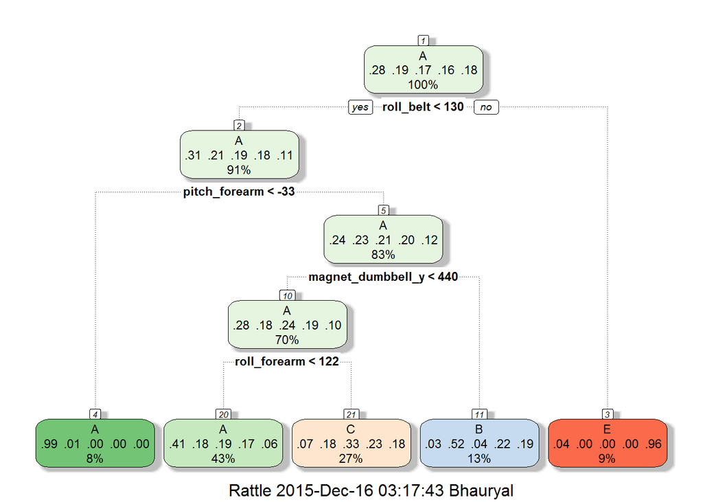

```r
fancyRpartPlot(modFit$finalModel)
```

Now run the prediction model against ptrain2

```r
# Run against ptrain2
predictions <- predict(modFit, ptrain2)
print(confusionMatrix(predictions, ptrain2$classe), digits=4)
```

```
## Confusion Matrix and Statistics
##
##           Reference
## Prediction    A    B    C    D    E
##          A 1491  489  488  426  150
##          B   24  375   35  178  134
##          C  131  275  503  360  293
##          D    0    0    0    0    0
##          E   28    0    0    0  505
##
## Overall Statistics
##
##                Accuracy : 0.4884
##                  95% CI : (0.4755, 0.5012)
##     No Information Rate : 0.2845
##     P-Value [Acc > NIR] : < 2.2e-16
##
##                   Kappa : 0.3315
##  Mcnemar's Test P-Value : NA
##
## Statistics by Class:
##
##                      Class: A Class: B Class: C Class: D Class: E
## Sensitivity            0.8907  0.32924  0.49025   0.0000  0.46673
## Specificity            0.6312  0.92183  0.78205   1.0000  0.99417
## Pos Pred Value         0.4898  0.50268  0.32202      NaN  0.94747
## Neg Pred Value         0.9356  0.85133  0.87902   0.8362  0.89219
## Prevalence             0.2845  0.19354  0.17434   0.1638  0.18386
## Detection Rate         0.2534  0.06372  0.08547   0.0000  0.08581
## Detection Prevalence   0.5172  0.12676  0.26542   0.0000  0.09057
## Balanced Accuracy      0.7609  0.62553  0.63615   0.5000  0.73045
```

### Random Forest

```r
#Train on training set 1 of 4 with only cross validation.
set.seed(666)
modFit <- train(ptrain1$classe ~ ., method="rf", trControl=trainControl(method = "cv", number = 4), data=ptrain1)
print(modFit, digits=3)
```

```
## Random Forest
##
## 13737 samples
##    53 predictor
##     5 classes: 'A', 'B', 'C', 'D', 'E'
##
## No pre-processing
## Resampling: Cross-Validated (4 fold)
## Summary of sample sizes: 10302, 10302, 10304, 10303
## Resampling results across tuning parameters:
##
##   mtry  Accuracy  Kappa  Accuracy SD  Kappa SD
##    2    0.993     0.992  0.001714     0.002169
##   27    0.997     0.996  0.000375     0.000475
##   53    0.992     0.990  0.002486     0.003146
##
## Accuracy was used to select the optimal model using  the largest value.
## The final value used for the model was mtry = 27.
```

Now run the prediction model against ptrain2

```r
predictions <- predict(modFit, newdata=ptrain2)
print(confusionMatrix(predictions, ptrain2$classe), digits=4)
```

```
## Confusion Matrix and Statistics
##
##           Reference
## Prediction    A    B    C    D    E
##          A 1674    0    0    0    0
##          B    0 1135    1    0    0
##          C    0    3 1025    6    0
##          D    0    1    0  957    3
##          E    0    0    0    1 1079
##
## Overall Statistics
##
##                Accuracy : 0.9975
##                  95% CI : (0.9958, 0.9986)
##     No Information Rate : 0.2845
##     P-Value [Acc > NIR] : < 2.2e-16
##
##                   Kappa : 0.9968
##  Mcnemar's Test P-Value : NA
##
## Statistics by Class:
##
##                      Class: A Class: B Class: C Class: D Class: E
## Sensitivity            1.0000   0.9965   0.9990   0.9927   0.9972
## Specificity            1.0000   0.9998   0.9981   0.9992   0.9998
## Pos Pred Value         1.0000   0.9991   0.9913   0.9958   0.9991
## Neg Pred Value         1.0000   0.9992   0.9998   0.9986   0.9994
## Prevalence             0.2845   0.1935   0.1743   0.1638   0.1839
## Detection Rate         0.2845   0.1929   0.1742   0.1626   0.1833
## Detection Prevalence   0.2845   0.1930   0.1757   0.1633   0.1835
## Balanced Accuracy      1.0000   0.9981   0.9986   0.9960   0.9985
```

```r
accuracy <- postResample(predictions, ptrain2$classe)
accuracy
```

```
##  Accuracy     Kappa
## 0.9974511 0.9967761
```

```r
oose <- 1 - as.numeric(confusionMatrix(predictions, ptrain2$classe)$overall[1])
oose
```

```
## [1] 0.002548853
```

### Predicting for Test Data Set

```r
pridictions<-predict(modFit, newdata=ptest)
print(pridictions)
```

```
##  [1] B A B A A E D B A A B C B A E E A B B B
## Levels: A B C D E
```

### Figures

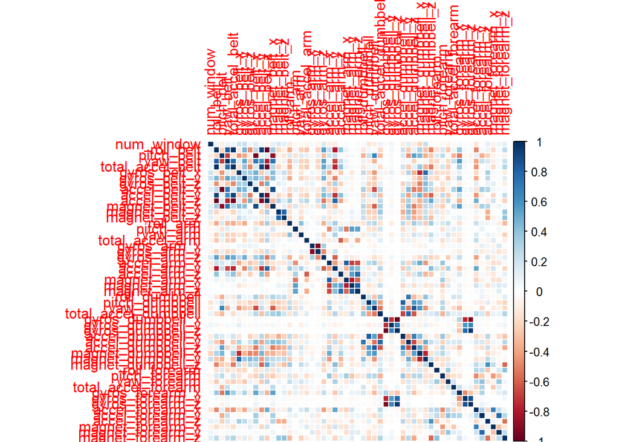

```r
corrPlot <- cor(ptrain1[, -length(names(ptrain1))])
corrplot(corrPlot, method="color")
```

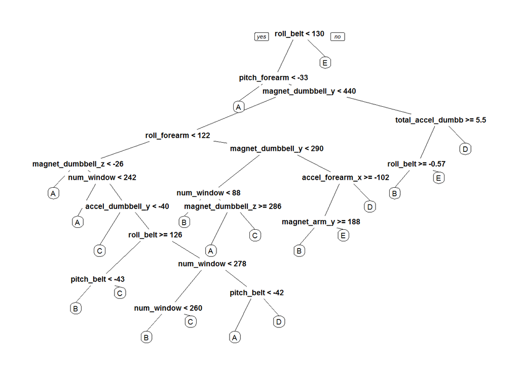

```r
treeModel <- rpart(classe ~ ., data=ptrain1, method="class")
prp(treeModel)
```